# “Big Data and Business Intellence”

“4. RFM Analysis”

“Wen-Bin Chuang”

“2023/07/24”

# Data-Driven Analytics

In data-driven analysis, firms collect consumers’ data and run them through data analytics tools to predict what the buyers need, why, where, and how. For example, Data-driven analysis is used by many brands to better **segment** their audiences. When brands have the right data, they can identify which consumers participate in their efforts, identify the best channels and narrow down the times of the day customers are most receptive.

- 客戶分群 consumer segment
- 同類群組分析 Cohort Analysis
- 客戶流失 Customer Churn analysis
- 購物籃分析 Market Basket Analysis
- 推薦系統 Recommendation Systems
- 歸因分析 Attribution Models

『客戶分群』RFM Analysis

The business problem

- **Problem**: we don’t understand our customer. We don’t know if a **specific** customer is relevant for our organization.

- Goals:
  - We want to know **how much value** a customer is generating for the organization.
  - We want to know how the **generated value** is going to evolve.
  - We want to **segment** customers based on value.

- **Why?** To perform specific actions for different customer groups

But attention, our organization is starting the customer analytics journey and we can not propose really sophisticated techniques

**RFM Analysis** is a customer segmentation method based on:

- **Recency**: How recently did the customer purchase?最近何時來消費
- **Frequency**: How often do they purchase? 多常來消費
- **Monetary**: How much do they spend in the specific period? 在特定期間內總共消費多少錢

It is easy to implement and understand. It is based on pareto principle: **20% of customers generate 80% of revenue**.

接下來，要用RFM三個指標去預測未來的消費行為，還是要根據消費者過去行為紀錄，找出一套模式，才能預測。

## Benefits

This technique provides the following benefits:

- It is a **customer segmentation** easy to calculate and understand
- Good fit for direct marketing: Which are the best segments? Who do I need to contact?
- Helps to improve CLV
- Helps to reduce churn (instead using other more complex techniques)
- Can be extended with location dimension (RFML)
- Provides some kind of insight about loyalty

原始資料為3個資料：`客戶ID`、`購買時間（日期格式）`、`購買金額`，用軟體處理，加權（考慮權重）得到RFM得分

| 名稱 | 定義 | 商業意義 |
| --- | --- | --- |
| Recency | 該消費者距離最近一次的購買時間（日） | 間隔時間*越短*可能對促銷活動越有反映 |
| Frequency | 該消費者至執行分析前所有的交易記錄筆數 | 交易記錄越多表示*忠誠度*越高 |
| Monetary | 該客戶至執行分析前的平均交易金額或總交易金額 | 金額越高表示對公司越有*商業價值 |

# 計算 RFM

```r
sales<-read.csv("sales2.csv", header=T, sep=",")
str(sales)
```

```
## 'data.frame':    10000 obs. of  3 variables:
##  $ CustomerId : int  1490 1203 1260 1647 1628 1779 1648 1999 1438 1888 ...
##  $ Sales.Value: int  27 27 8 22 41 13 28 8 11 44 ...
##  $ sales.dates: chr  "2019/1/1" "2019/1/1" "2019/1/1" "2019/1/1" ...
```

```r
# 就用設定時間 和sales.dates的差異
time <- "2019-12-31"
sales$recency1=round(as.numeric(difftime(time,sales[,3],units="days")) )

# rename recency 光顧天數 frequency 購買次數
names(sales)<-c("CustomerId", "Purchase.Value", "sales.dates","recency")

#統計每個用戶的消費總值 sales[,2] 是Purchase.Value
salesM=aggregate(sales[,2],list(sales$CustomerId),sum)
names(salesM)=c("CustomerId","Monetization")

salesF=aggregate(sales[,2],list(sales$CustomerId),length)
names(salesF)=c("CustomerId","Frequency")

salesR=aggregate(sales[,4],list(sales$CustomerId),min) #依recency
names(salesR)=c("CustomerId","Recency")
```

```r
##Merging R,F,M
# merge:將兩個DF融合成一個DF，merge(x, y, by = intersect(names(x), names(y)) ）
test1=merge(salesF,salesR,"CustomerId")

salesRFM=merge(salesM,test1,"CustomerId")
head(salesRFM)
```

```
##   CustomerId Monetization Frequency Recency
## 1       1000          186         7    -278
## 2       1001          241        10    -217
## 3       1002          299         9    -288
## 4       1003          184         8    -198
## 5       1004          506        20    -334
## 6       1005          277         9    -243
```

# RFM Distribution

## Recency 光顧天數 Histogram, Boxplot

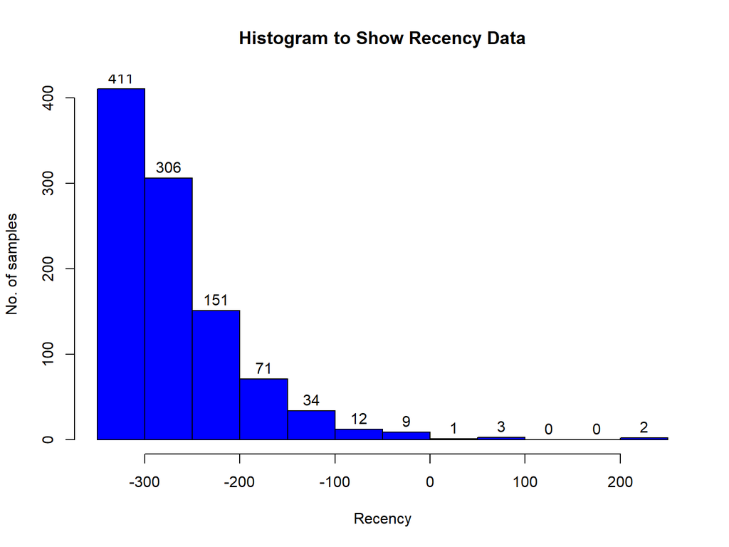

```r
hist(salesRFM$Recency,
     col="blue",
     main="Histogram to Show Recency Data",
     xlab="Recency",
     ylab="No. of samples",
     labels=TRUE)
```

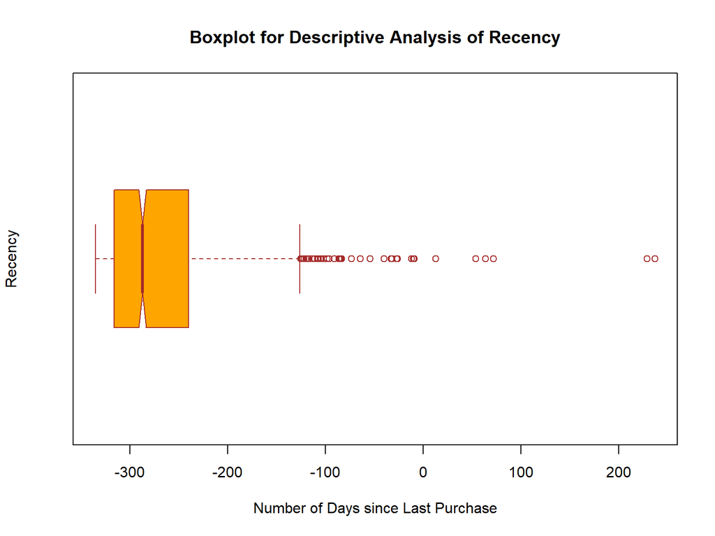

```r
boxplot(salesRFM$Recency,
        main = "Boxplot for Descriptive Analysis of Recency",
        xlab = "Number of Days since Last Purchase",
        ylab = "Recency",
        col = "orange",
        border = "brown",
        horizontal = TRUE,
        notch = TRUE)
```

## 購買次數 Density Plot, Boxplot

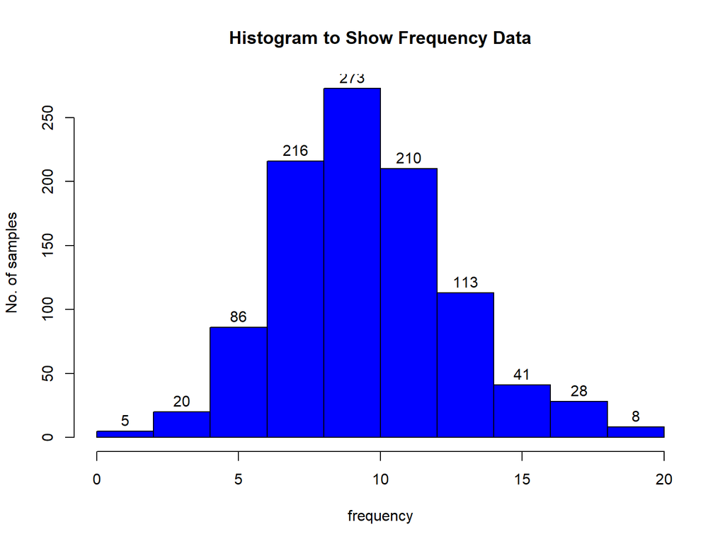

```r
hist(salesRFM$Frequency,
     col="blue",
     main="Histogram to Show Frequency Data",
     xlab="frequency",
     ylab="No. of samples",
     labels=TRUE)
```

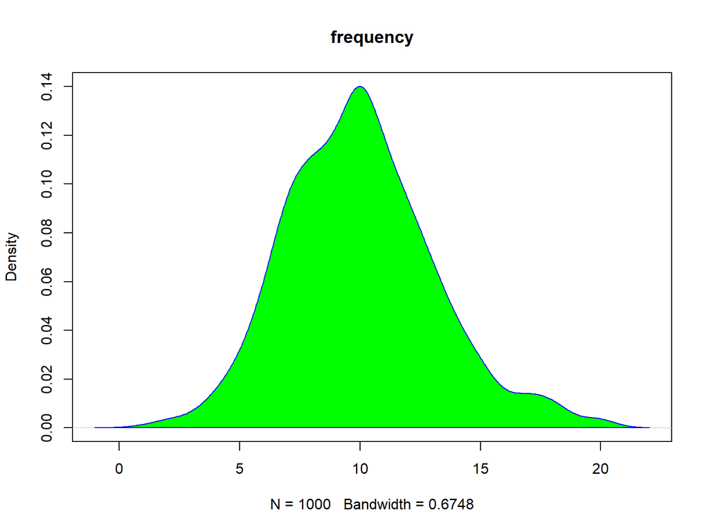

```r
d1_f = density(salesRFM$Frequency)
plot(d1_f, main="frequency")
polygon(d1_f, col="green", border="blue")
```

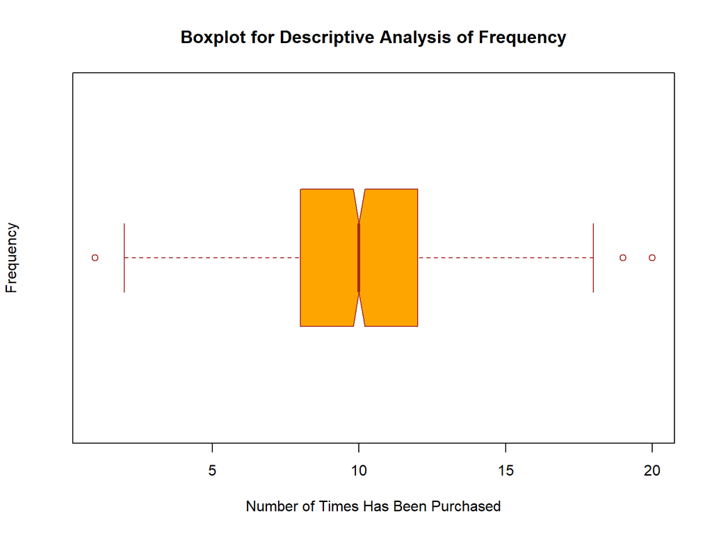

```r
boxplot(salesRFM$Frequency,
        main = "Boxplot for Descriptive Analysis of Frequency",
        xlab = "Number of Times Has Been Purchased",
        ylab = "Frequency",
        col = "orange",
        border = "brown",
        horizontal = TRUE,
        notch = TRUE)
```

```r
## itemFrequencyPlot(salesRFM$Frequency, topN = 10, type = ’absolute’)
```

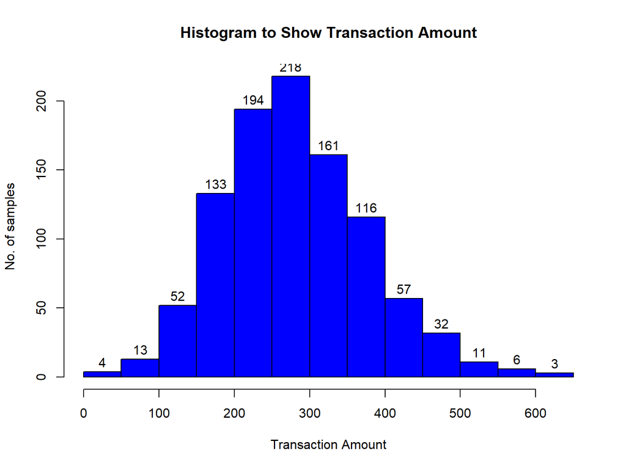

```r
hist(salesRFM$Monetization,
     col="blue",
     main="Histogram to Show Transaction Amount",
     xlab="Transaction Amount",
     ylab="No. of samples",
     labels=TRUE)
```

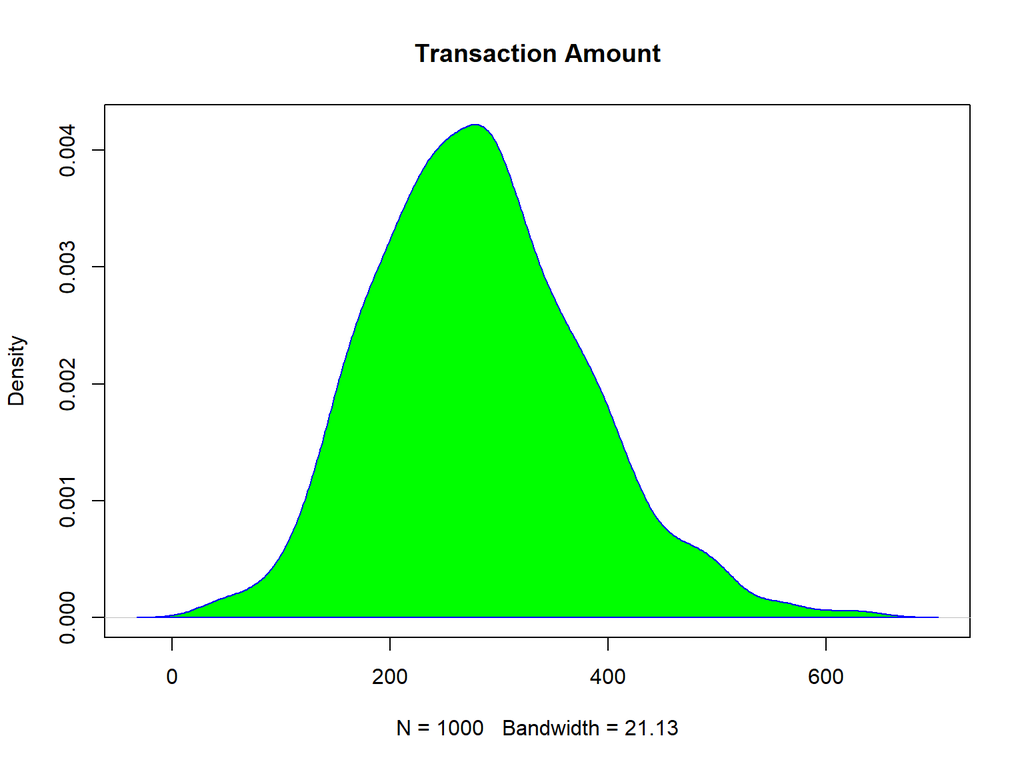

```r
d1_a = density(salesRFM$Monetization)
plot(d1_a, main="Transaction Amount")
polygon(d1_a, col="green", border="blue")
```

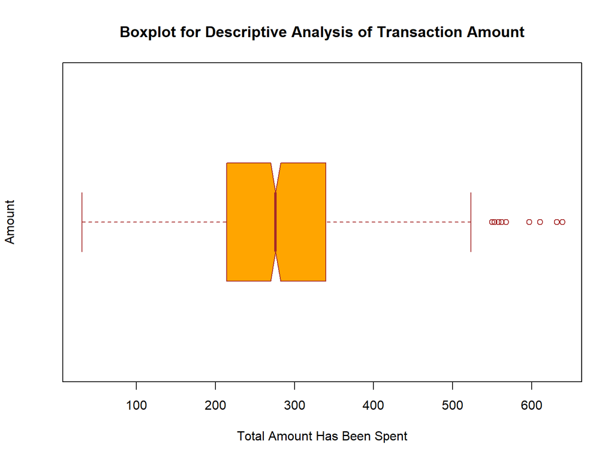

```r
boxplot(salesRFM$Monetization,
        main = "Boxplot for Descriptive Analysis of Transaction Amount",
        xlab = "Total Amount Has Been Spent",
        ylab = "Amount",
        col = "orange",
        border = "brown",
        horizontal = TRUE,
        notch = TRUE)
```

[figure not shown]

```r
library(scatterplot3d)
#remove the first column (customer_id)
salesRFM = salesRFM[,-1]
scatterplot3d(salesRFM[, c(1,2,3)], pch=20, angle=80, main='Original 3D plot',
              xlab='Recency', ylab='Frequency',
              zlab='Transaction Amount')
```

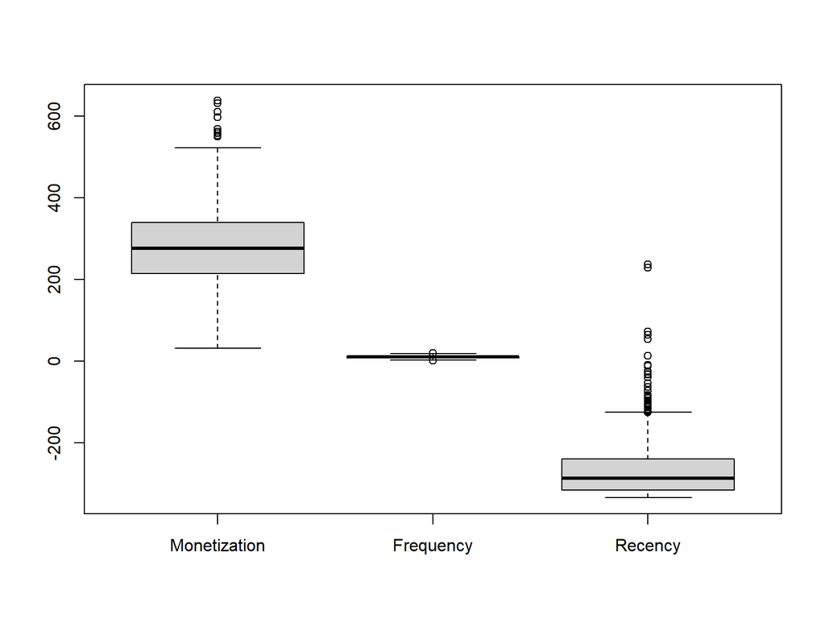

```r
boxplot(salesRFM)
```

# RFM

## 客戶群數所代表的意義

| Rank | Recency | Frequency | Monetary | 客戶類型 |
| --- | --- | --- | --- | --- |
| 1 | 高於均值 | 高於均值 | 高於均值 | 最有價值客戶 |
| 2 | 高於均值 | 低於均值 | 高於均值 | 重要發展客戶 |
| 3 | 低於均值 | 高於均值 | 高於均值 | 重要保持客戶 |
| 4 | 低於均值 | 低於均值 | 高於均值 | 重要挽留客戶 |
| 5 | 高於均值 | 高於均值 | 低於均值 | 一般價值客戶 |
| 6 | 高於均值 | 低於均值 | 低於均值 | 一般發展客戶 |
| 7 | 低於均值 | 高於均值 | 低於均值 | 一般保持客戶 |
| 8 | 低於均值 | 低於均值 | 低於均值 | 一般挽留客戶 |

| Rank | 客戶類型 | 商業意義 | 是否為 MVP |
| --- | --- | --- | --- |
| 1 | 最有價值客戶 | 能替公司帶來最多利益，需長期培養 | V |
| 2 | 重要發展客戶 | 雖然購買頻率低，但不表示未來不會成為 MVP | V |
| 3 | 重要保持客戶 | 雖然最近購買時間低於均值，但不表示未來不會成為 MVP | V |
| 4 | 重要挽留客戶 | 曾經購買大量產品的客戶，需研究購買內容、購買動機甚至為何不再消費 | V |
| 5 | 一般價值客戶 | 替公司帶來一定程度收益的客戶，仍然有透過促銷提升價值的可能性 | X |
| 6 | 一般發展客戶 | 最近有消費記錄，仍然有透過促銷提升價值的可能性 | X |
| 7 | 一般保持客戶 | 替公司帶來一定程度收益的客戶，仍然有透過促銷提升價值的可能性 | X |
| 8 | 一般挽留客戶 | 一般客戶 | X |

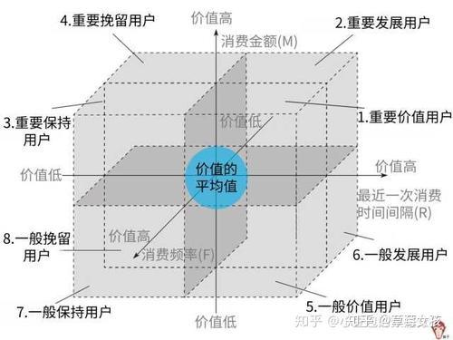

機器學習來 8分法

- 以**kmeans**作說明 （可有 FCM, ….)

## Basic information

```r
salesRFM2 <- salesRFM
row.names(salesRFM2) <- salesRFM2$CustomerID
salesRFM2$CustomerID <- NULL
salesRFM2 <- scale(salesRFM2) # normalization
summary(salesRFM2)
```

```
##   Monetization        Frequency          Recency
##  Min.   :-2.60266   Min.   :-2.9127   Min.   :-0.9935
##  1st Qu.:-0.69817   1st Qu.:-0.6473   1st Qu.:-0.7133
##  Median :-0.05293   Median : 0.0000   Median :-0.2857
##  Mean   : 0.00000   Mean   : 0.0000   Mean   : 0.0000
##  3rd Qu.: 0.60532   3rd Qu.: 0.6473   3rd Qu.: 0.4073
##  Max.   : 3.72484   Max.   : 3.2363   Max.   : 7.4410
```

```r
set.seed(123)
km.res <- kmeans(salesRFM2, 8, nstart = 25)
dd <- cbind(salesRFM2, cluster = km.res$cluster)
head(dd, 50)
```

```
##       Monetization  Frequency      Recency cluster
##  [1,]  -0.98956703 -0.9709019 -0.152986371       8
##  [2,]  -0.41717796  0.0000000  0.746499763       6
##  [3,]   0.18643232 -0.3236340 -0.300443115       7
##  [4,]  -1.01038118 -0.6472679  1.026667576       1
##  [5,]   2.34069662  3.2363396 -0.978744134       2
##  [6,]  -0.04252330 -0.3236340  0.363112231       6
##  [7,]  -0.03211623  0.6472679 -0.403662835       7
##  [8,]  -0.01130208  0.3236340 -0.934507111       7
##  [9,]   1.09184775  0.3236340 -0.742813345       5
## [10,]  -0.24025771  0.0000000 -0.492136881       7
## [11,]   0.76922846  0.6472679  3.356484122       4
## [12,]  -0.56287700 -0.6472679 -0.772304694       7
## [13,]  -0.78142555 -0.3236340 -0.728067671       7
## [14,]  -0.22985063  0.0000000 -0.831287391       7
```

[output cut: 36 more lines]

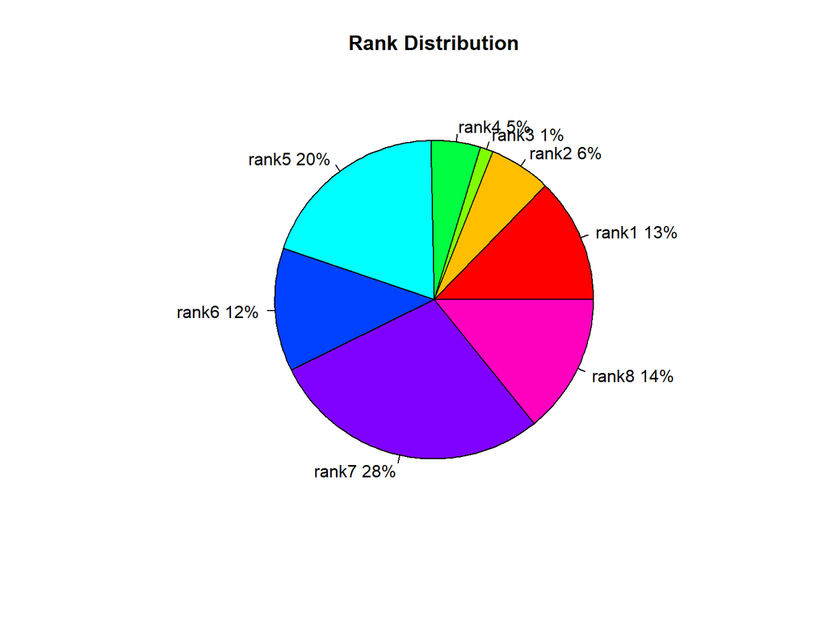

```r
slices <- km.res$size
lbls <- c("rank1", "rank2", "rank3", "rank4", "rank5", "rank6", "rank7", "rank8") # since the cluster number is 8
pct <- round(slices/sum(slices)*100)
lbls <- paste(lbls, pct) # add percents to labels
lbls <- paste(lbls,"%",sep="") # ad % to labels
pie(slices,labels = lbls, col=rainbow(length(lbls)), main="Rank Distribution")
```

Clustering - unsupervised learning

`Cluster analysis` is used to identify groups of **similar** objects in a multivariate data sets for marketing, bio-medical and geo-spatial. It is an **unsupervised** machine learning task that automatically divides the data into clusters, or groups of similar items.

Clustering is guided by the principle that items inside a cluster should be very similar to each other, but very different from those outside.

The classification of observations into groups requires some methods for computing the **distance** or the (dis)similarity between each pair of observations. The result of this computation is known as a **dissimilarity or distance matrix**. There are different methods for measuring distances, including: Euclidean distance and Correlation based-distance

## k-means clustering algorithm

We can assign each of the **n** examples to one of the **k** clusters. The goal is to minimize the differences within each cluster and maximize the differences between the clusters.

**It is not feasible to compute the optimal clusters** across all the possible combinations of examples. As with k-means treats feature values as coordinates in a multidimensional feature space. The k-means algorithm begins by **choosing k points** in the feature space to serve as the cluster centers.

The algorithm is sensitive to **the number of clusters**. Setting k to be very large will improve the homogeneity of the clusters, and at the same time, it risks overfitting the data.

## How to choose the K

Ideally, you will have **a priori knowledge (a prior belief)** about the true groupings and you can apply this information to choosing the number of clusters.

Without any prior knowledge, one **rule of thumb** suggests setting $k$ equal to **the square root of (n / 2)**, where n is the number of examples in the dataset. A technique known as the **elbow metho**d attempts to gauge how the homogeneity or heterogeneity within the clusters changes for various values of k. This value of k is known as the elbow point because it looks like an elbow.

## Elbow Method

For **K-Means**, we have to set a number of **clusters** for our data to be divided into. Since this is, at first, a completely arbitrary task, we have to look for options to make it as precise as possible.

One of the most popular methods to do so is the **Elbow Method**. Basically, we calculate different scenarios for different numbers of clusters and then plot them in a line.

使用k-means得到客户群數

```r
salesRFM2 <- salesRFM
row.names(salesRFM2) <- salesRFM2$CustomerID
salesRFM2$CustomerID <- NULL
salesRFM2 <- scale(salesRFM2) # normalization
summary(salesRFM2)
```

```
##   Monetization        Frequency          Recency
##  Min.   :-2.60266   Min.   :-2.9127   Min.   :-0.9935
##  1st Qu.:-0.69817   1st Qu.:-0.6473   1st Qu.:-0.7133
##  Median :-0.05293   Median : 0.0000   Median :-0.2857
##  Mean   : 0.00000   Mean   : 0.0000   Mean   : 0.0000
##  3rd Qu.: 0.60532   3rd Qu.: 0.6473   3rd Qu.: 0.4073
##  Max.   : 3.72484   Max.   : 3.2363   Max.   : 7.4410
```

```r
# Sometimes, it is terrible
# install.packages("factoextra")
library(factoextra)
```

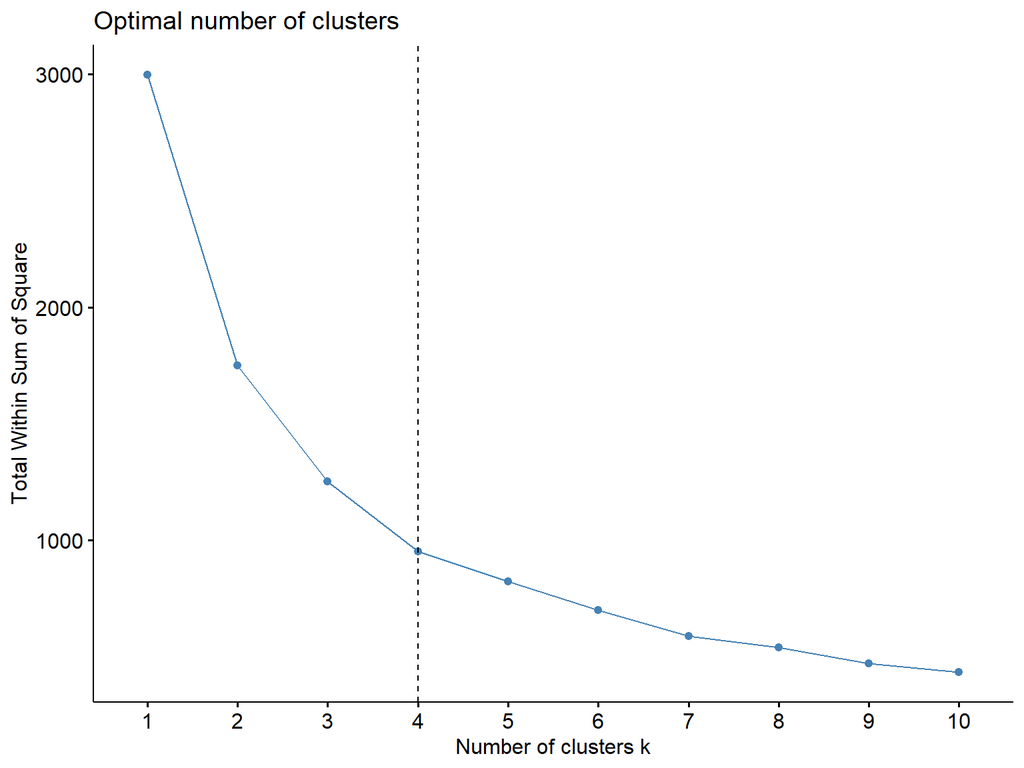

```r
fviz_nbclust(salesRFM2, kmeans, method ="wss") +
        geom_vline(xintercept = 4, linetype =2)
```

```r
# It is OK
set.seed(123)
# Compute and plot wss for k = 2 to k = 15.
k.max <- 15
data <- salesRFM2[,1:3]
wss <- sapply(1:k.max,
        function(k){
           kmeans(data, k, nstart=50,iter.max = 15)$tot.withinss
        }
       )
```

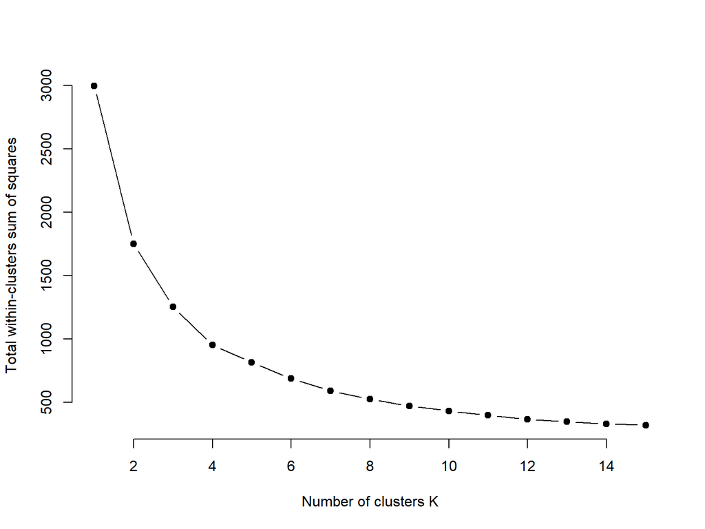

```r
plot(1:k.max, wss,
     type="b", pch = 19, frame = FALSE,
     xlab="Number of clusters K",
     ylab="Total within-clusters sum of squares")
```

```r
m1 <- kmeans(salesRFM2, 4) #設定cluster number is 4
table(m1$cluster)
```

```
##
##   1   2   3   4
## 270 130 185 415
```

對細分的客戶群進行特徵分析

```r
# distrution
m2 <- table(m1$cluster)
m2 <- as.data.frame(m2)
m21 <- as.factor(m2[,1])
m22 <- m2[,2]
m3 <- data.frame(m21, m22)
```

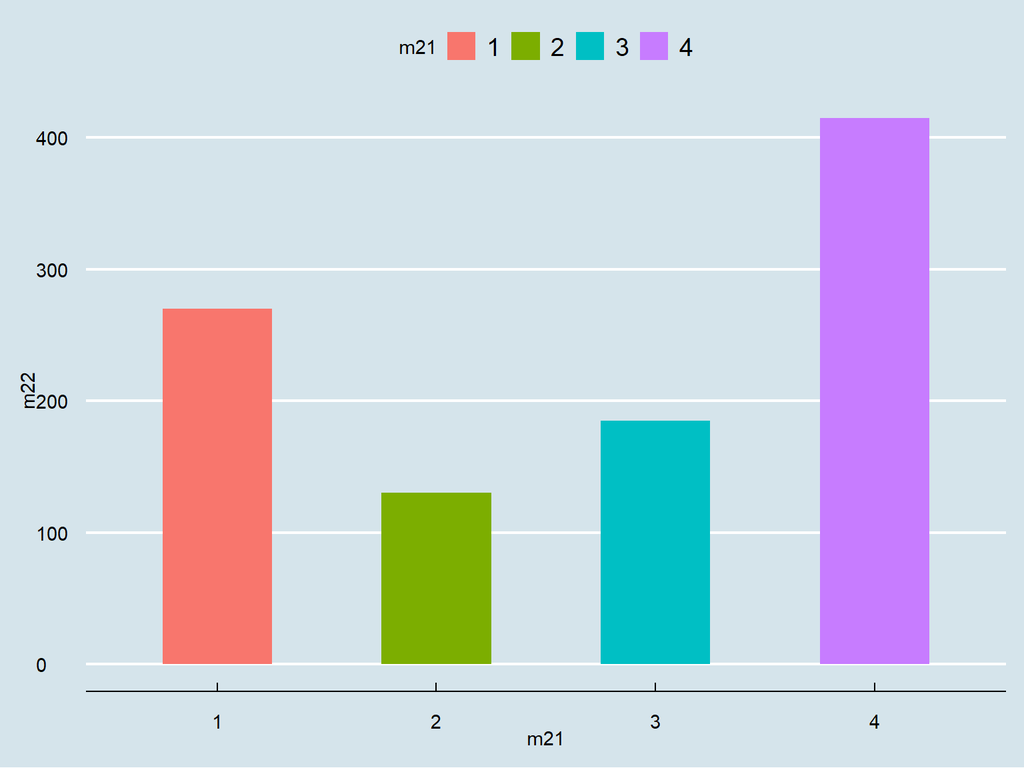

```r
#install.packages("ggthemes")
library(ggthemes)
library(ggplot2)
ggplot(m3, aes(x = m21, y = m22, fill = m21)) +
  geom_bar(stat = "identity", width = 0.5) +
  theme_economist()
```

```r
  geom_text(aes(label = m22, vjust = -0.8, hjust = 0.5, color = m21))
```

```
## mapping: label = ~m22, vjust = ~-0.8, hjust = 0.5, colour = ~m21
## geom_text: parse = FALSE, check_overlap = FALSE, na.rm = FALSE
## stat_identity: na.rm = FALSE
## position_identity
```

```r
r.df1 <- aggregate(salesRFM[, 1:3], by = list(m1$cluster), mean)
t1 <- r.df1
t1$Group.1 <- NULL
t1 <- scale(t1)
group <- c("1", "2", "3", "4")
t2 <- data.frame(group, t1)
t2 <- t(data.frame(t2, row.names =1))
t3 <- as.data.frame(t2, row.names =F)
labs <- c("recency", "frequency", "Monetary")
t4 <- list("1" = t3[,1], "2" = t3[,2], "3" = t3[,3], "4" = t3[,4])
```

```r
# install.packages("radarchart")
library(radarchart)
chartJSRadar(scores = t4, labs =labs, showRoolTipLabel = FALSE)
```

[interactive chart not shown]

傳統8分法

```r
#create RFM 三等分
getRFMinterval <- function(RFMdata, interval, original){
  #get min value
  # 獲得三等分所需的 interval , GeneralInterval=max(Rencency)-min(Rencency)/3
  maxData <- max(RFMdata)
  minData <- min(RFMdata)
  factorInterval <- (maxData-minData)/interval
  difference <- RFMdata - minData

  # 獲得該筆 Rencency 的群數 -Rank = (Recency - min(Rencency))/GeneralInterval
  return(
    if(!original){
      ifelse(difference>0, ceiling(difference/factorInterval), 1)
    }
    else {
      ifelse(difference>0, difference/factorInterval, 1)
    }
  )
}
```

```r
salesRFM$rankR <- getRFMinterval(salesRFM$Recency, 3, F)
salesRFM$rankF <- getRFMinterval(salesRFM$Frequency, 3, F)
salesRFM$rankM <- getRFMinterval(salesRFM$Monetization,3, F)
head(salesRFM)
```

```
##   Monetization Frequency Recency rankR rankF rankM
## 1          186         7    -278     1     1     1
## 2          241        10    -217     1     2     2
## 3          299         9    -288     1     2     2
## 4          184         8    -198     1     2     1
## 5          506        20    -334     1     3     3
## 6          277         9    -243     1     2     2
```

```r
str(salesRFM)
```

```
## 'data.frame':    1000 obs. of  6 variables:
##  $ Monetization: int  186 241 299 184 506 277 278 280 386 258 ...
##  $ Frequency   : int  7 10 9 8 20 9 12 11 11 10 ...
##  $ Recency     : num  -278 -217 -288 -198 -334 -243 -295 -331 -318 -301 ...
##  $ rankR       : num  1 1 1 1 1 1 1 1 1 1 ...
##  $ rankF       : num  1 2 2 2 3 2 2 2 2 2 ...
##  $ rankM       : num  1 2 2 1 3 2 2 2 2 2 ...
```

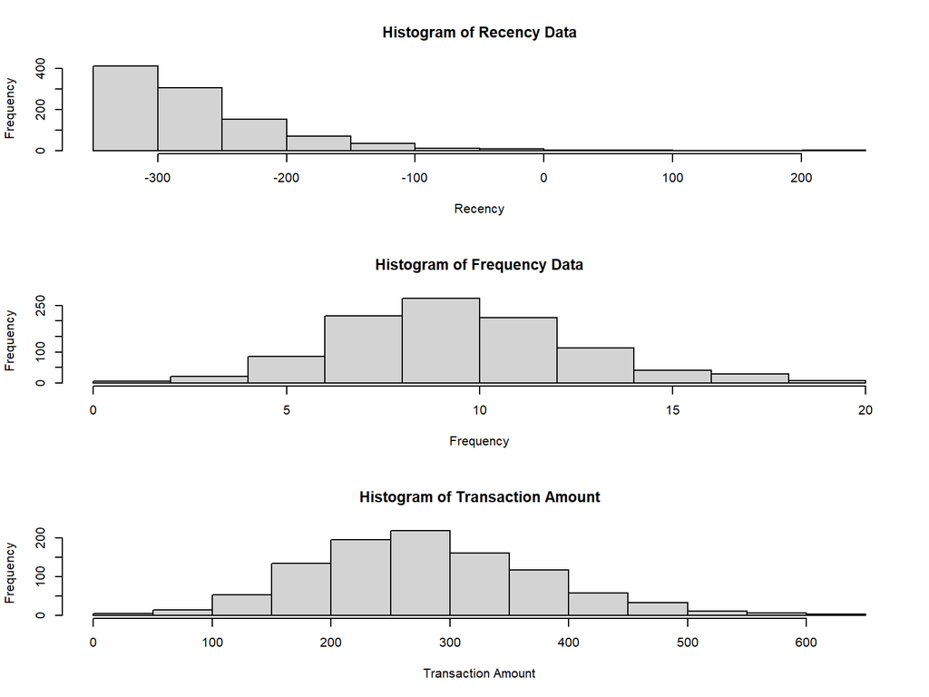

```r
par(mfrow = c(3,1))
hist(salesRFM$Recency, main = 'Histogram of Recency Data', xlab = 'Recency')
hist(salesRFM$Frequency, main = 'Histogram of Frequency Data', xlab = 'Frequency')
hist(salesRFM$Monetization, main = 'Histogram of Transaction Amount', xlab = 'Transaction Amount')
```

```r
#create weight
salesRFM$Weight <- salesRFM$rankR*100+salesRFM$rankF*10+salesRFM$rankM # 權重計算方法為 R*100+F*10+M
head(salesRFM)
```

```
##   Monetization Frequency Recency rankR rankF rankM Weight
## 1          186         7    -278     1     1     1    111
## 2          241        10    -217     1     2     2    122
## 3          299         9    -288     1     2     2    122
## 4          184         8    -198     1     2     1    121
## 5          506        20    -334     1     3     3    133
## 6          277         9    -243     1     2     2    122
```

```r
# 按5%，20%，50%，100%的區間將客戶分類，分別為“重要客戶”，“一般重要客戶”，“一般客戶”，“低價值客戶”。分類規則由實際業務制定。
library(dplyr)
max.num <- max(dense_rank(desc(salesRFM$Weight)))
salesRFM <- salesRFM %>% mutate(
  rank = dense_rank(desc(salesRFM$Weight)),
  `Consumer_type` = cut(
    rank, breaks = c(0, 0.05*max.num, 0.2*max.num, 0.5*max.num, max.num),
    include.lowest = T, right = T,
    labels = c("重要客戶", "一般重要客戶", "一般客戶", "低價值客戶")
  )
)
head(salesRFM, 100)
```

```
##     Monetization Frequency Recency rankR rankF rankM Weight rank Consumer_type
## 1            186         7    -278     1     1     1    111   14    低價值客戶
## 2            241        10    -217     1     2     2    122   11    低價值客戶
## 3            299         9    -288     1     2     2    122   11    低價值客戶
## 4            184         8    -198     1     2     1    121   12    低價值客戶
## 5            506        20    -334     1     3     3    133    8    低價值客戶
## 6            277         9    -243     1     2     2    122   11    低價值客戶
## 7            278        12    -295     1     2     2    122   11    低價值客戶
## 8            280        11    -331     1     2     2    122   11    低價值客戶
## 9            386        11    -318     1     2     2    122   11    低價值客戶
## 10           258        10    -301     1     2     2    122   11    低價值客戶
## 11           355        12     -40     2     2     2    222    4      一般客戶
## 12           227         8    -320     1     2     1    121   12    低價值客戶
## 13           206         9    -317     1     2     1    121   12    低價值客戶
## 14           259        10    -324     1     2     2    122   11    低價值客戶
```

[output cut: 86 more lines]

```r
# Another method
#基準值
R.mean <- mean(salesRFM$rankR)
F.mean <- mean(salesRFM$rankF)
M.mean <- mean(salesRFM$rankM)
#使用case_when分類
salesRFM <- salesRFM %>% mutate(
  Consumer_type2 = case_when(
    salesRFM$rankR > R.mean & salesRFM$rankF > F.mean & salesRFM$rankM > M.mean ~ "重要客户",
    salesRFM$rankR < R.mean & salesRFM$rankF > F.mean & salesRFM$rankM > M.mean ~ "一般重要客户",
    salesRFM$rankR > R.mean & salesRFM$rankF < F.mean & salesRFM$rankM > M.mean ~ "一般",
    salesRFM$rankR < R.mean & salesRFM$rankF < F.mean & salesRFM$rankM < M.mean ~ "低价值客户",
    TRUE ~ "其他分類"  #默認為其他分類
  )
)
head(salesRFM, 20)
```

```
##    Monetization Frequency Recency rankR rankF rankM Weight rank Consumer_type
## 1           186         7    -278     1     1     1    111   14    低價值客戶
## 2           241        10    -217     1     2     2    122   11    低價值客戶
## 3           299         9    -288     1     2     2    122   11    低價值客戶
## 4           184         8    -198     1     2     1    121   12    低價值客戶
## 5           506        20    -334     1     3     3    133    8    低價值客戶
## 6           277         9    -243     1     2     2    122   11    低價值客戶
## 7           278        12    -295     1     2     2    122   11    低價值客戶
## 8           280        11    -331     1     2     2    122   11    低價值客戶
## 9           386        11    -318     1     2     2    122   11    低價值客戶
## 10          258        10    -301     1     2     2    122   11    低價值客戶
## 11          355        12     -40     2     2     2    222    4      一般客戶
## 12          227         8    -320     1     2     1    121   12    低價值客戶
## 13          206         9    -317     1     2     1    121   12    低價值客戶
## 14          259        10    -324     1     2     2    122   11    低價值客戶
```

[output cut: 27 more lines]

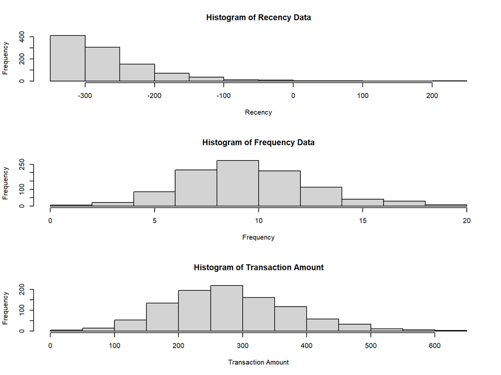

```r
par(mfrow = c(3,1))
hist(salesRFM$Recency, main = 'Histogram of Recency Data', xlab = 'Recency')
hist(salesRFM$Frequency, main = 'Histogram of Frequency Data', xlab = 'Frequency')
hist(salesRFM$Monetization, main = 'Histogram of Transaction Amount', xlab = 'Transaction Amount')
```

```r
#create weight
salesRFM$Weight <- salesRFM$rankR*100+salesRFM$rankF*10+salesRFM$rankM # 權重計算方法為 R*100+F*10+M
head(salesRFM)
```

```
##   Monetization Frequency Recency rankR rankF rankM Weight rank Consumer_type
## 1          186         7    -278     1     1     1    111   14    低價值客戶
## 2          241        10    -217     1     2     2    122   11    低價值客戶
## 3          299         9    -288     1     2     2    122   11    低價值客戶
## 4          184         8    -198     1     2     1    121   12    低價值客戶
## 5          506        20    -334     1     3     3    133    8    低價值客戶
## 6          277         9    -243     1     2     2    122   11    低價值客戶
##   Consumer_type2
## 1     低价值客户
## 2   一般重要客户
## 3   一般重要客户
## 4       其他分類
## 5   一般重要客户
## 6   一般重要客户
```

```r
##Looking at RFM tables
# 以table形式查看
table(salesRFM[,4:5])
```

```
##      rankF
## rankR   1   2   3
##     1 187 638 119
##     2  22  27   2
##     3   5   0   0
```

```r
table(salesRFM[,4:6])
```

```
## , , rankM = 1
##
##      rankF
## rankR   1   2   3
##     1 174 119   0
##     2  21   6   0
##     3   5   0   0
##
## , , rankM = 2
##
##      rankF
## rankR   1   2   3
##     1  13 516  64
##     2   1  21   1
##     3   0   0   0
##
## , , rankM = 3
##
##      rankF
## rankR   1   2   3
##     1   0   3  55
##     2   0   0   1
##     3   0   0   0
```

```r
table(salesRFM[,5:6])
```

```
##      rankM
## rankF   1   2   3
##     1 200  14   0
##     2 125 537   3
##     3   0  65  56
```